# Unsupervised Machine Learning II: Principal Componennt Analysis (PCA)

Gepoliano Chaves

March 8th, 2024

## 1. Introduction

- Principal Component Analysis (PCA) is a dimensionality reduction technique used to transform a high dimensional data set into data of lesser dimensions while minimizing the loss of information Gatto (2023b).
- The goal of PCA is to reduce the number of dimensions in a way that the new data remains useful Gatto (2023a).
- Principal components are uncorrelated and explain the variation in the data Sanchez (2012).
- For this activity, we want to investigate if the patterns of mutation frequencies are similar across all different countries for which we have calculated the mutation frequency.
  - We are interested in finding out which regions have similar mutation frequency patterns.
    - If two regions have similar mutation frequencies, they may need to enter lock-down together.
- This activity is based on the article of Keita (2023).

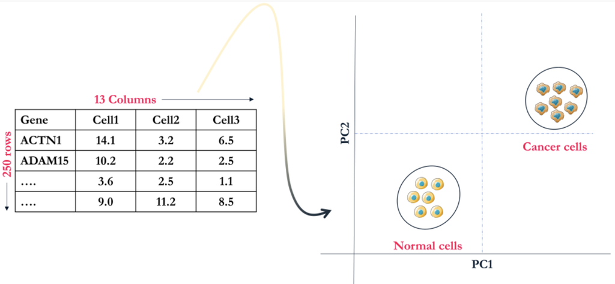

Principal Component Analysis (PCA). Figure from All (n.d.).

### Question

- Which mutation pattern (frequency) or the mutation pattern of which region contributes the most to the viral evolution success?
  - Performing a PCA analysis is to find which variable contributes the most to the variation or variability observed in the data.
    - The data is organized such that regions are in columns and SNP mutations are in lines.

## 2. Load and Pre-Process Data

### 2.1. Load libraries

```r
library("corrr")
library("ggcorrplot")
library("FactoMineR")
```

### 2.2. Read the COVID-19 Frequency Table data

- Read file and transform into matrix.

```r
heatmap_table <- read.table("./data/temp_file.txt", row.names = 1, header = TRUE, sep = "\t")
heatmap_table = as.matrix(heatmap_table)
```

### 2.3. Apply normalization methods

#### 2.3.1. Log-transformation

- We used this method with in the hierarchical clustering analysis.

```r
log_table_09_18_2020 = log (heatmap_table + 1)
```

- You can use the View() function to compare the heatmap_table object to the log-normalized object log_table_09_18_2020

#### 2.3.2. Normalization using the scale() function

- The scale() function centers and/or scales the columns of a numeric matrix
- Check the ?scale() command in the terminal

```r
covid19_normalized <- scale(log_table_09_18_2020)
```

- Use the View() function to compare the heatmap_table object to the covid19_normalized object

## 3. Correlation matrix and Principal Components

### 3.1 Compute matrix

```r
corr_matrix_covid19 <- cor(covid19_normalized)
```

- After computing the correlation matrix, take a look at it using the View() function
- Finally, visualize the correlation matrix using the ggcorrplot() function:

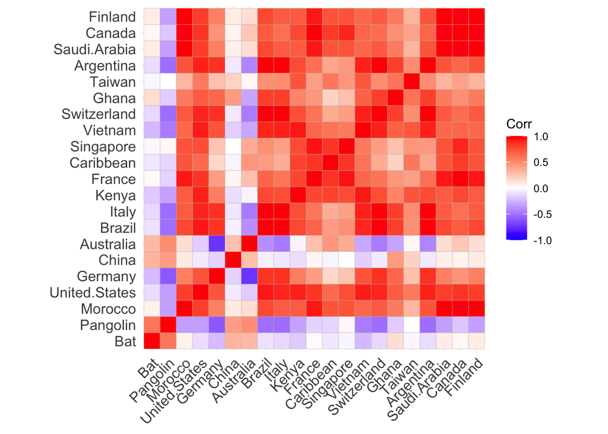

```r
ggcorrplot(corr_matrix_covid19)
```

- The higher the value, the most positively correlated two variables are;
- The closer the value is to -1, the most negatively correlated the variables are.
- Notice that the values in the diagonal are all 1s (ones), in the table and in the figure, showing that the vector of each country has 100% correlation with itself.
- Notice that pangolin and bat are highly related to each other. Therefore we could make these samples a single group or cluster.

### 3.2. Apply PCA

- Use the princomp() function to perform principal component analysis on numeric data matrix

```r
data.pca.covid19 <- princomp(corr_matrix_covid19)
```

### 3.3. R PCA summary

```r
summary(data.pca.covid19)
```

```
## Importance of components:
##                           Comp.1    Comp.2     Comp.3     Comp.4      Comp.5
## Standard deviation     1.5537510 0.6448268 0.29815295 0.21516132 0.143299403
## Proportion of Variance 0.8049738 0.1386453 0.02964129 0.01543645 0.006847116
## Cumulative Proportion  0.8049738 0.9436191 0.97326042 0.98869687 0.995543986
##                             Comp.6     Comp.7       Comp.8       Comp.9
## Standard deviation     0.097454945 0.05606876 0.0228735888 1.394565e-02
## Proportion of Variance 0.003166844 0.00104824 0.0001744567 6.484801e-05
## Cumulative Proportion  0.998710831 0.99975907 0.9999335277 9.999984e-01
##                             Comp.10      Comp.11      Comp.12      Comp.13
## Standard deviation     2.207083e-03 1.028103e-08 8.215746e-09 6.765235e-09
## Proportion of Variance 1.624262e-06 3.524459e-17 2.250676e-17 1.526106e-17
## Cumulative Proportion  1.000000e+00 1.000000e+00 1.000000e+00 1.000000e+00
##                             Comp.14      Comp.15      Comp.16      Comp.17
## Standard deviation     5.282957e-09 2.946671e-09 1.890226e-09 4.097262e-10
## Proportion of Variance 9.306216e-18 2.895224e-18 1.191370e-18 5.597659e-20
## Cumulative Proportion  1.000000e+00 1.000000e+00 1.000000e+00 1.000000e+00
##                        Comp.18 Comp.19 Comp.20 Comp.21
## Standard deviation           0       0       0       0
## Proportion of Variance       0       0       0       0
## Cumulative Proportion        1       1       1       1
```

- We notice that 21 principal components have been generated (Comp. 1 to Comp. 21).
- Each component explains a percentage of the total variance in the dataset.
- Observe in the **Cumulative Proportion** section that principal component 1 explains 80.5% of the total variance.
- The cumulative proportion of PC1 and PC2 explains more than 94% of the total variance.
- As an implication, PC1 and PC2 accurately represent the data.
- We can proceed to visualize the variation of the data on the PC1 and PC2 axis.

### 3.4. Loadings of Principal Components PC1 and PC2

```r
data.pca.covid19$loadings[,1:2]
```

```
##                   Comp.1      Comp.2
## Bat            0.1544871  0.01158916
## Pangolin       0.2597580 -0.07575888
## Morocco       -0.2009474 -0.20930827
## United.States -0.2609286 -0.04956442
## Germany       -0.2871305  0.22279994
## China          0.1229201  0.06560957
## Australia      0.1809527 -0.44442262
## Brazil        -0.2860625  0.10503311
## Italy         -0.2881171  0.15645226
## Kenya         -0.2314182 -0.12631596
## France        -0.1700501 -0.30862891
## Caribbean     -0.1205562 -0.39165138
## Singapore     -0.1203687 -0.35957044
## Vietnam       -0.2747472  0.03896998
## Switzerland   -0.2881065  0.15147938
## Ghana         -0.1692771  0.23061445
## Taiwan        -0.1050006  0.01575087
## Argentina     -0.2875630  0.13432779
## Saudi.Arabia  -0.2004996 -0.20905042
## Canada        -0.1795863 -0.28918512
## Finland       -0.2006158 -0.20913027
```

- The loading matrix shows PC1 with high values for Bat, Pangolin, China and Australia.
- For USA, Brazil, Italy, Germany and Canada for instance, the PC1 values are negative.
- This suggests that COVID-19 samples with frequencies similar to original bat and pangolin infection are in deficit while countries with different frequencies are in excess.
- For PC2, a pattern is not clear except for a correlation to the latitude of the mutation frequencies.
  - Australia is on the global south, as is Brazil, but PC2 is negative for Australia but positive for Brazil.
  - If we consider the traffic between countries, PC2 may explain proximity of Italy and Germany and Italy and Brazil.
  - The first COVID-19 case in Brazil was imported from Italy.

## 4. Visualization of the Principal Components

- The previous visualization gave a good understanding of the relationship between each of the first two principal components and attributes in the data.
- However, this does not help visualization.
- In this part we will generate visualization of the principal components.

### 4.1. Scree Plot

- The first visualization approach is the scree plot.
- The scree plot is used to visualize the importance of each Principal Component in accounting for variability present in the data.
- This graph can be used to determine the number of PC to retain that explain the variability present in the data Wikipedia (n.d.).
- We load the R package factoextra, because we will use a function from this package.

```r
library(factoextra)
```

- The function we need to use is fviz_eig(); in the console you can type ?fviz_eig() to obtain more information about this function.

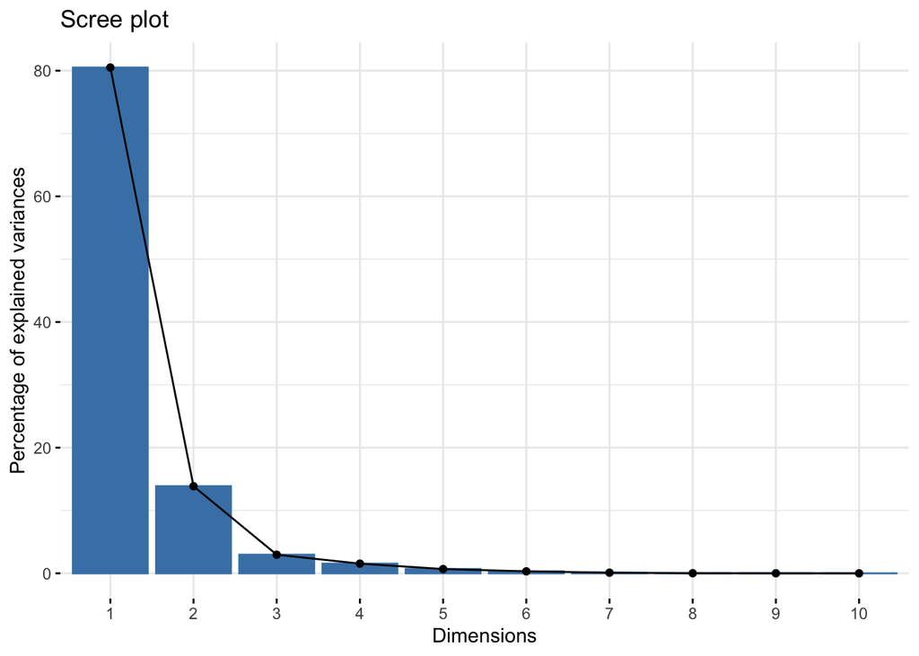

```r
fviz_eig(data.pca.covid19)
```

- Now we will add the addlabels parameters set to TRUE.

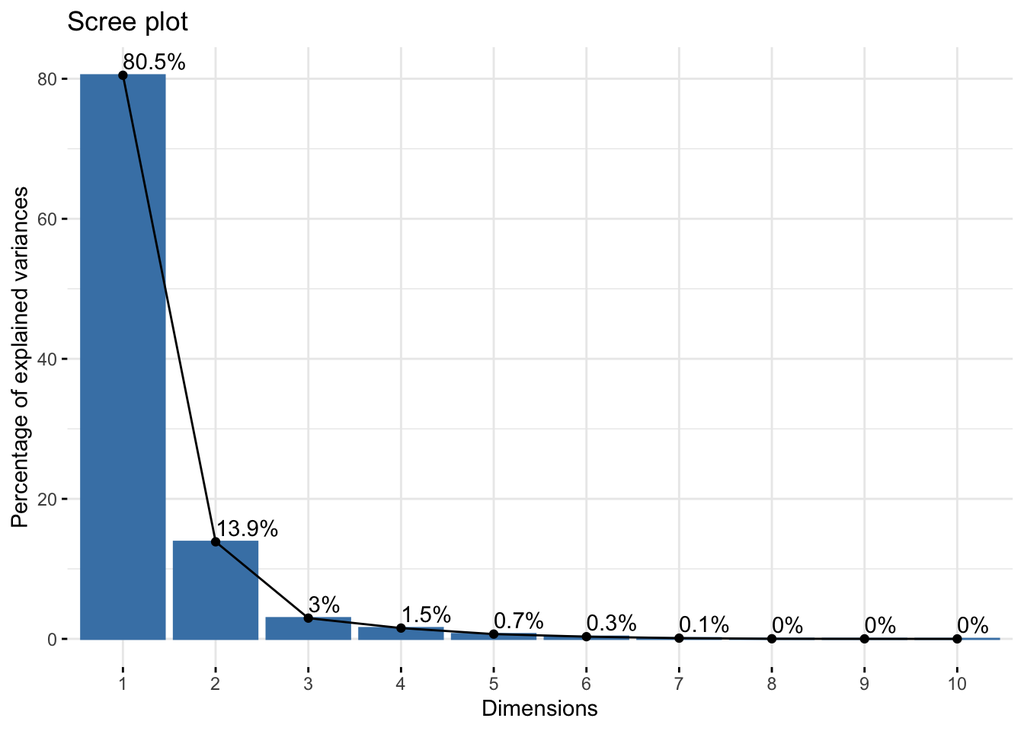

```r
fviz_eig(data.pca.covid19, addlabels = TRUE)
```

- This plot shows the eigenvalues in a downward curve, from highest to lowest.
- More than 94% of variation is explained by PC1 and PC2.

### 4.2. BiPlot of the attributes

- BiPlots are used to show similarities and dissimilarities between the samples.
- BiPlots show the impact of each attribute (country) on each of the principal components

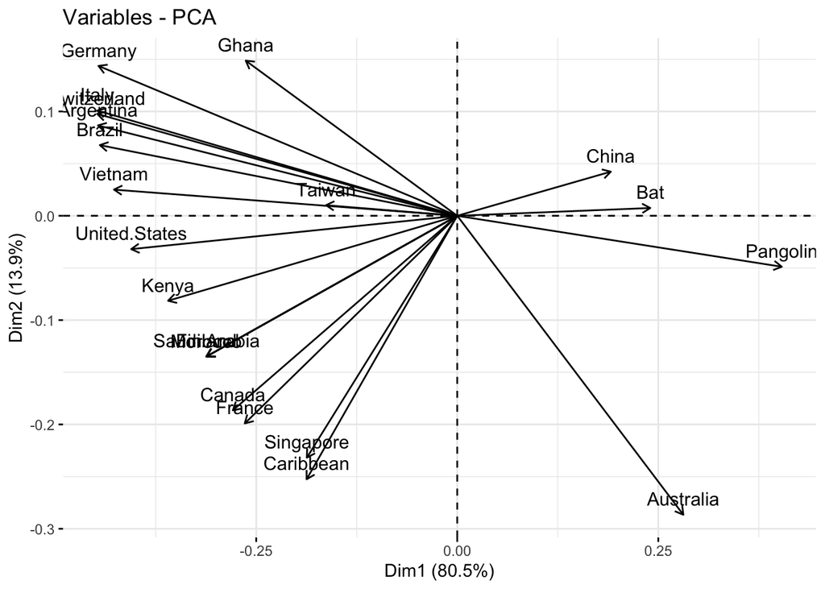

```r
fviz_pca_var(data.pca.covid19, col.var = "black")
```

- Conclusions from the BiPlot figure
  - Variables grouped together are positively related to each other
  - The higher the distance from the origin, the better represented the variable is
  - Variables negatively correlate
- For the sake of simplicity, let’s assume PC1 to relate to longitude and PC2 to relate to the latitude of the country.

## 5. Contribution of each variable to the Principal Component Variation

- This quantification is achieved with the square cosine
- We use the fviz_cos2() function
- Low value means the variable is not perfectly represented by the component.
- High value means a good representation of the value on the component.

### 5.1. Representation of each region in PC1

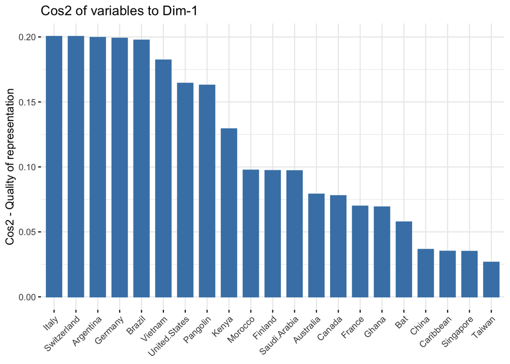

```r
fviz_cos2(data.pca.covid19, choice = "var", axes = 1)
```

### 5.2. Representation of each region in PC2

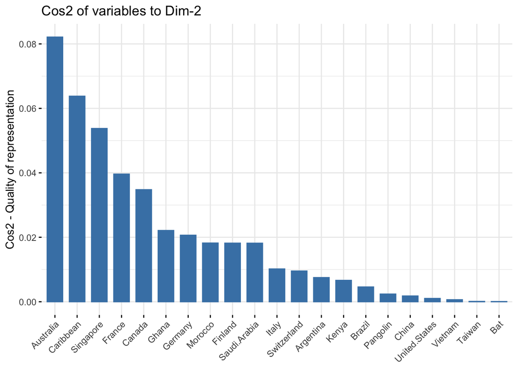

```r
fviz_cos2(data.pca.covid19, choice = "var", axes = 2)
```

### 5.3. Representation of each region in PC1 and PC2

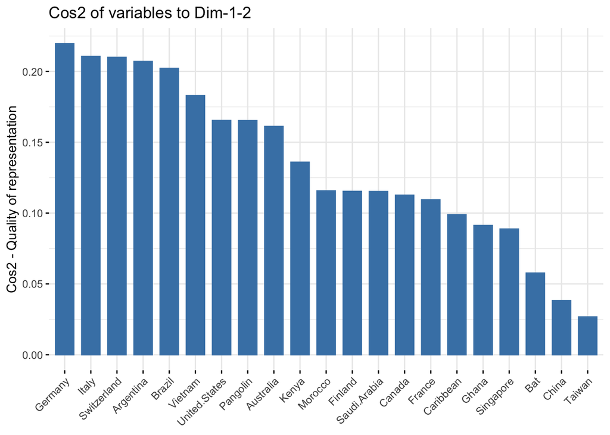

```r
fviz_cos2(data.pca.covid19, choice = "var", axes = 1:2)
```

### 5.4. Biplot combined with cos2

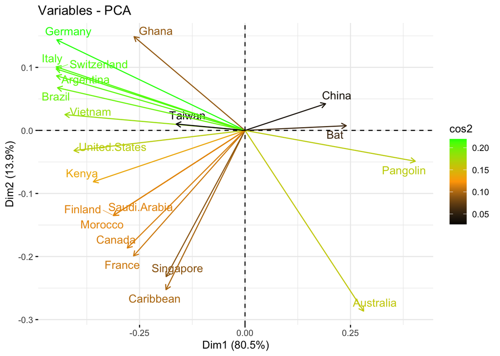

```r
fviz_pca_var(data.pca.covid19, col.var = "cos2",
            gradient.cols = c("black", "orange", "green"),
            repel = TRUE)
```

- From the biplot:
  - Argentina, Brazil, Italy, Germany and Switzerland have high cos2 attributes and are colored in green: these samples contribute the highest scores to PC1 and PC2.
  - France, Finland, Saudi Arabia, Morocco and Canada have mid cos2 attributes and are colored orange.
  - China, Bat and Taiwan have low cos2 and are colored black: these samples contribute the lowest to the variability of PC1 and PC2.
- Compare to the square cosine, from above.

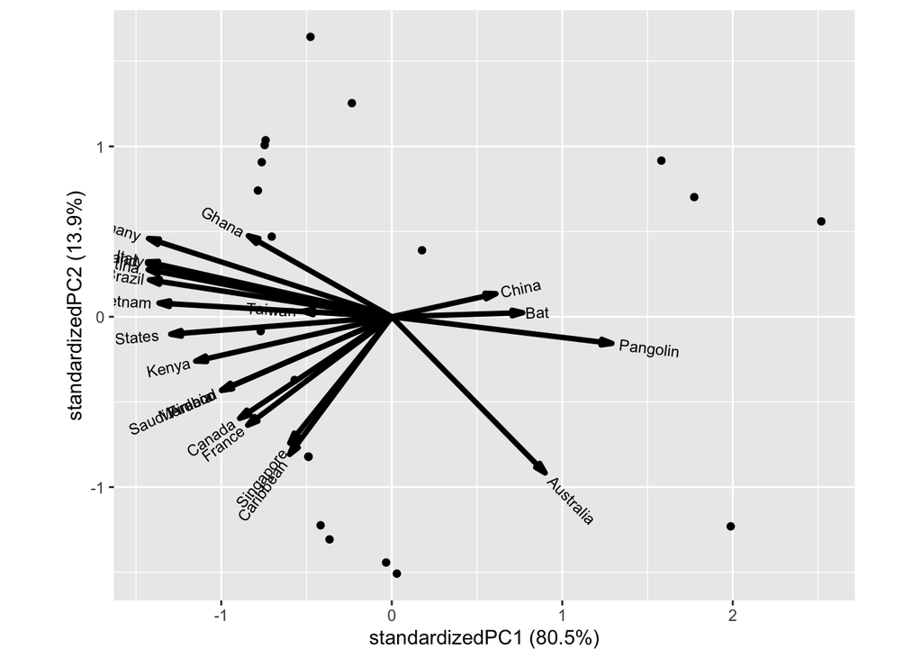

```r
library("ggbiplot")
ggbiplot(data.pca.covid19)
```

## 6. References

All, Bioinformatics for. n.d. *Tutorial 6: How to Do Principal Component Analysis (PCA) in r*. Accessed February 4, 2024. https://bioinfo4all.wordpress.com/2021/01/31/tutorial-6-how-to-do-principal-component-analysis-pca-in-r/.

Gatto, Laurent. 2023a. *Chapter 4 Manipulating Sequences with Biostrings*. https://uclouvain-cbio.github.io/WSBIM1322/sec-biostrings.html.

———. 2023b. *Chapter 8 Unsupervised Learning: Dimensionality Reduction*. https://uclouvain-cbio.github.io/WSBIM1322/sec-dimred.html.

Keita, Zoumana. 2023. *Principal Component Analysis in r Tutorial*. https://www.datacamp.com/tutorial/pca-analysis-r.

Sanchez, Gaston. 2012. *5 Functions to Do Principal Components Analysis in r*. https://www.gastonsanchez.com/visually-enforced/how-to/2012/06/17/PCA-in-R/.

Wikipedia. n.d. *Scree Plot*. Accessed March 26, 2024. https://en.wikipedia.org/wiki/Scree_plot#:~:text=In%20multivariate%20statistics%2C%20a%20scree,principal%20component%20analysis%20(PCA).